# Chicago Bulls Team Analysis

Ryan Ahchee

# 1. Introduction

### Description

The Chicago Bulls are a team that competes in the NBA (National Basketball Association). In the most recent NBA season they placed 27th out of 30 (based on win-loss record).

The task by the general manager of Chicago Bulls is to find the best five starting players (one from each position) your team can afford but still having the ability to fill a full team roster. For the purpose of this task, we are focused on finding five starting players and can include players already on the Chicago Bulls roster.

### Background on Key Basketball Metrics

The basics of basket ball is to score more points than the opposition. Throughout this report we will reference the Olivers Four Factors [https://www.basketball-reference.com/about/factors.html].

Reference: 1. Squared Statistics: Understanding Basketball Analytics. (2017). Introduction to Oliver’s Four Factors. Available at: https://goo.gl/PXJiUw [Accessed 09 May. 2021].

The basic premise of this is that there are four effective ways to win more basketball games. The four factors are: * to score efficiently * protect the basketball on offense * grab as many rebounds as possible * and get to the foul line as often as possible.

Each of these elements are closely related to the termination of a possession for a team. Oliver expands this to metrics.

- Shooting: measured in effective field goal percentage (eFG%)
- Turnovers: measured in turnover percentage (TOV%)
- Rebounding: measured in offensive and defensive rebounding percentage (ORB% and DRB%)
- Free throws,: measured in free throw rate (FTR)

We will use these as a starting point using basic data analysis techniques for exploring, describing and summarizing data in order to provide recommendation on the best stating players for the Chicago Bull NBA team with a $118M salary cap.

### Aim of Project

Provide recommendations to to General Manager on best recruitment players for the Chicago Bulls starting team by using basic data analysis techniques for exploring, describing and summarising data.

# 2. Reading and cleaning data

## Load required packages

```r
library(tidyverse) # include all required packages at the start
library(tidyr)
library(broom)
library(dplyr)
library(magrittr)
library(knitr)
```

## Data source

The data used in this document contains match data form the National Basketball League for season 2018-19.

The sources are refernces below: 1. 2018-19_nba_player-statistics.csv : sourced frombasketball-reference.com 2. 2018-19_nba_player-salaries.csv :sourced from hoopshype.com/salaries 3. 2019-20_nba_team-payroll.csv : sourced from hoopshype.com/salaries 4. 2018-19_nba_team-statistics_1.csv : sourced from basketball-reference.com 5. 2018-19_nba_team-statistics_2.csv : sourced from basketball-reference.com

A description of all data variable descriptions can be found at in the `README.rmd`

## Read data

Read in the all data using file using the `read.csv()` function from the `readr` package.

```r
# data dir should be in the raw working dirictory

# read in player stats 1
df_player <- read.csv("data/raw/2018-19_nba_player-statistics.csv")

# read in player salaries
df_player_salaries <- read.csv("data/raw/2018-19_nba_player-salaries.csv")

# read in team stats 1
df_team_stats_1 <- read.csv("data/raw/2018-19_nba_team-statistics_1.csv")

# read in team stats 1
df_team_stats_2 <- read.csv("data/raw/2018-19_nba_team-statistics_2.csv")

# read team payroll data
df_team_payroll <- read.csv("data/raw/2019-20_nba_team-payroll.csv")
```

## Checking the Data & Exploratory Analysis

Check the structure of the data file using `str()`:

```r
str(df_player)
```

```
## 'data.frame':    708 obs. of  29 variables:
##  $ player_name: chr  "Alex Abrines" "Quincy Acy" "Jaylen Adams" "Steven Adams" ...
##  $ Pos        : chr  "SG" "PF" "PG" "C" ...
##  $ Age        : int  25 28 22 25 21 21 25 33 21 23 ...
##  $ Tm         : chr  "OKC" "PHO" "ATL" "OKC" ...
##  $ G          : int  31 10 34 80 82 19 7 81 10 38 ...
##  $ GS         : int  2 0 1 80 28 3 0 81 1 2 ...
##  $ MP         : int  588 123 428 2669 1913 194 22 2687 120 416 ...
##  $ FG         : int  56 4 38 481 280 11 3 684 13 67 ...
##  $ FGA        : int  157 18 110 809 486 36 10 1319 39 178 ...
##  $ FG.        : num  0.357 0.222 0.345 0.595 0.576 0.306 0.3 0.519 0.333 0.376 ...
##  $ X3P        : int  41 2 25 0 3 6 0 10 3 32 ...
##  $ X3PA       : int  127 15 74 2 15 23 4 42 12 99 ...
##  $ X3P.       : num  0.323 0.133 0.338 0 0.2 0.261 0 0.238 0.25 0.323 ...
##  $ X2P        : int  15 2 13 481 277 5 3 674 10 35 ...
##  $ X2PA       : int  30 3 36 807 471 13 6 1277 27 79 ...
##  $ X2P.       : num  0.5 0.667 0.361 0.596 0.588 0.385 0.5 0.528 0.37 0.443 ...
##  $ eFG.       : num  0.487 0.278 0.459 0.595 0.579 0.389 0.3 0.522 0.372 0.466 ...
##  $ FT         : int  12 7 7 146 166 4 1 349 8 45 ...
##  $ FTA        : int  13 10 9 292 226 4 2 412 12 60 ...
##  $ FT.        : num  0.923 0.7 0.778 0.5 0.735 1 0.5 0.847 0.667 0.75 ...
##  $ ORB        : int  5 3 11 391 165 3 1 251 11 3 ...
##  $ DRB        : int  43 22 49 369 432 16 3 493 15 20 ...
##  $ TRB        : int  48 25 60 760 597 19 4 744 26 23 ...
##  $ AST        : int  20 8 65 124 184 5 6 194 13 25 ...
##  $ STL        : int  17 1 14 117 71 1 2 43 1 6 ...
##  $ BLK        : int  6 4 5 76 65 4 0 107 0 6 ...
##  $ TOV        : int  14 4 28 135 121 6 2 144 8 33 ...
##  $ PF         : int  53 24 45 204 203 13 4 179 7 47 ...
##  $ PTS        : int  165 17 108 1108 729 32 7 1727 37 211 ...
```

```r
str(df_player_salaries)
```

```
## 'data.frame':    576 obs. of  3 variables:
##  $ player_id  : int  1 2 3 4 5 6 7 8 9 10 ...
##  $ player_name: chr  "Alex Abrines" "Quincy Acy" "Steven Adams" "Jaylen Adams" ...
##  $ salary     : int  3667645 213948 24157304 236854 2955840 77250 5285394 77250 2000000 22347015 ...
```

```r
str(df_team_stats_1)
```

```
## 'data.frame':    30 obs. of  25 variables:
##  $ ï..Rk : int  1 2 3 4 5 6 7 8 9 10 ...
##  $ Team  : chr  "Milwaukee Bucks" "Golden State Warriors" "Toronto Raptors" "Utah Jazz" ...
##  $ Age   : num  26.9 28.4 27.3 27.3 29.2 26.2 24.9 25.7 25.7 27 ...
##  $ W     : int  60 57 58 50 53 53 54 49 49 48 ...
##  $ L     : int  22 25 24 32 29 29 28 33 33 34 ...
##  $ PW    : int  61 56 56 54 53 51 51 52 50 50 ...
##  $ PL    : int  21 26 26 28 29 31 31 30 32 32 ...
##  $ MOV   : num  8.87 6.46 6.09 5.26 4.77 4.2 3.95 4.44 3.4 3.33 ...
##  $ SOS   : num  -0.82 -0.04 -0.6 0.03 0.19 0.24 0.24 -0.54 0.15 -0.57 ...
##  $ SRS   : num  8.04 6.42 5.49 5.28 4.96 4.43 4.19 3.9 3.56 2.76 ...
##  $ ORtg  : num  114 116 113 111 116 ...
##  $ DRtg  : num  105 110 107 106 111 ...
##  $ NRtg  : num  8.6 6.4 6 5.2 4.8 4.2 4.1 4.4 3.3 3.4 ...
##  $ Pace  : num  103.3 100.9 100.2 100.3 97.9 ...
##  $ FTr   : num  0.255 0.227 0.247 0.295 0.279 0.258 0.232 0.215 0.266 0.242 ...
##  $ X3PAr : num  0.419 0.384 0.379 0.394 0.519 0.339 0.348 0.381 0.347 0.292 ...
##  $ TS.   : num  0.583 0.596 0.579 0.572 0.581 0.568 0.558 0.567 0.545 0.561 ...
##  $ eFG.  : num  0.55 0.565 0.543 0.538 0.542 0.528 0.527 0.534 0.514 0.53 ...
##  $ TOV.  : num  12 12.6 12.4 13.4 12 12.1 11.9 11.5 11.7 12.4 ...
##  $ ORB.  : num  20.8 22.5 21.9 22.9 22.8 26.6 26.6 21.6 26 21.9 ...
##  $ FT.FGA: num  0.197 0.182 0.198 0.217 0.221 0.21 0.175 0.173 0.19 0.182 ...
##  $ DRB.  : num  80.3 77.1 77.1 80.3 74.4 77.9 78 77 78.2 76.2 ...
##  $ X     : logi  NA NA NA NA NA NA ...
##  $ X.1   : logi  NA NA NA NA NA NA ...
##  $ X.2   : logi  NA NA NA NA NA NA ...
```

```r
str(df_team_stats_2)
```

```
## 'data.frame':    30 obs. of  25 variables:
##  $ ï..Rk: int  1 2 3 4 5 6 7 8 9 10 ...
##  $ Team : chr  "Milwaukee Bucks" "Golden State Warriors" "New Orleans Pelicans" "Philadelphia 76ers" ...
##  $ G    : int  82 82 82 82 82 82 82 82 82 82 ...
##  $ MP   : int  19780 19805 19755 19805 19830 19855 19855 19880 19730 19930 ...
##  $ FG   : int  3555 3612 3581 3407 3384 3470 3497 3460 3541 3456 ...
##  $ FGA  : int  7471 7361 7563 7233 7178 7427 7706 7305 7637 7387 ...
##  $ FG.  : num  0.476 0.491 0.473 0.471 0.471 0.467 0.454 0.474 0.464 0.468 ...
##  $ X3P  : int  1105 1087 842 889 821 904 932 1015 927 930 ...
##  $ X3PA : int  3134 2824 2449 2474 2118 2520 2677 2771 2455 2731 ...
##  $ X3P. : num  0.353 0.385 0.344 0.359 0.388 0.359 0.348 0.366 0.378 0.341 ...
##  $ X2P  : int  2450 2525 2739 2518 2563 2566 2565 2445 2614 2526 ...
##  $ X2PA : int  4337 4537 5114 4759 5060 4907 5029 4534 5182 4656 ...
##  $ X2P. : num  0.565 0.557 0.536 0.529 0.507 0.523 0.51 0.539 0.504 0.543 ...
##  $ FT   : int  1471 1339 1462 1742 1853 1558 1461 1449 1354 1508 ...
##  $ FTA  : int  1904 1672 1921 2258 2340 1914 2049 1803 1865 1963 ...
##  $ FT.  : num  0.773 0.801 0.761 0.771 0.792 0.814 0.713 0.804 0.726 0.768 ...
##  $ ORB  : int  762 797 909 892 796 967 1031 786 906 794 ...
##  $ DRB  : int  3316 2990 2969 3025 2936 2968 2911 2920 2819 2679 ...
##  $ TRB  : int  4078 3787 3878 3917 3732 3935 3942 3706 3725 3473 ...
##  $ AST  : int  2136 2413 2216 2207 1970 1887 1917 2085 2083 2154 ...
##  $ STL  : int  615 625 610 606 561 546 766 680 679 683 ...
##  $ BLK  : int  486 525 441 432 385 413 425 437 363 379 ...
##  $ TOV  : int  1137 1169 1215 1223 1193 1135 1145 1150 1095 1154 ...
##  $ PF   : int  1608 1757 1732 1745 1913 1669 1839 1724 1751 1701 ...
##  $ PTS  : int  9686 9650 9466 9445 9442 9402 9387 9384 9363 9350 ...
```

```r
str(df_team_payroll)
```

```
## 'data.frame':    30 obs. of  3 variables:
##  $ ï..team_id: int  1 2 3 4 5 6 7 8 9 10 ...
##  $ team      : chr  "Miami " "Golden State " "Oklahoma City " "Toronto " ...
##  $ salary    : chr  "$153,171,497 " "$146,291,276 " "$144,916,427 " "$137,793,831 " ...
```

Check the first 6 rows of the data file using `head()`

```r
head(df_player)
```

```
##    player_name Pos Age  Tm  G GS   MP  FG FGA   FG. X3P X3PA  X3P. X2P X2PA
## 1 Alex Abrines  SG  25 OKC 31  2  588  56 157 0.357  41  127 0.323  15   30
## 2   Quincy Acy  PF  28 PHO 10  0  123   4  18 0.222   2   15 0.133   2    3
## 3 Jaylen Adams  PG  22 ATL 34  1  428  38 110 0.345  25   74 0.338  13   36
## 4 Steven Adams   C  25 OKC 80 80 2669 481 809 0.595   0    2 0.000 481  807
## 5  Bam Adebayo   C  21 MIA 82 28 1913 280 486 0.576   3   15 0.200 277  471
## 6    Deng Adel  SF  21 CLE 19  3  194  11  36 0.306   6   23 0.261   5   13
##    X2P.  eFG.  FT FTA   FT. ORB DRB TRB AST STL BLK TOV  PF  PTS
## 1 0.500 0.487  12  13 0.923   5  43  48  20  17   6  14  53  165
## 2 0.667 0.278   7  10 0.700   3  22  25   8   1   4   4  24   17
## 3 0.361 0.459   7   9 0.778  11  49  60  65  14   5  28  45  108
## 4 0.596 0.595 146 292 0.500 391 369 760 124 117  76 135 204 1108
## 5 0.588 0.579 166 226 0.735 165 432 597 184  71  65 121 203  729
## 6 0.385 0.389   4   4 1.000   3  16  19   5   1   4   6  13   32
```

```r
head(df_player)
```

```
##    player_name Pos Age  Tm  G GS   MP  FG FGA   FG. X3P X3PA  X3P. X2P X2PA
## 1 Alex Abrines  SG  25 OKC 31  2  588  56 157 0.357  41  127 0.323  15   30
## 2   Quincy Acy  PF  28 PHO 10  0  123   4  18 0.222   2   15 0.133   2    3
## 3 Jaylen Adams  PG  22 ATL 34  1  428  38 110 0.345  25   74 0.338  13   36
## 4 Steven Adams   C  25 OKC 80 80 2669 481 809 0.595   0    2 0.000 481  807
## 5  Bam Adebayo   C  21 MIA 82 28 1913 280 486 0.576   3   15 0.200 277  471
## 6    Deng Adel  SF  21 CLE 19  3  194  11  36 0.306   6   23 0.261   5   13
##    X2P.  eFG.  FT FTA   FT. ORB DRB TRB AST STL BLK TOV  PF  PTS
## 1 0.500 0.487  12  13 0.923   5  43  48  20  17   6  14  53  165
## 2 0.667 0.278   7  10 0.700   3  22  25   8   1   4   4  24   17
## 3 0.361 0.459   7   9 0.778  11  49  60  65  14   5  28  45  108
## 4 0.596 0.595 146 292 0.500 391 369 760 124 117  76 135 204 1108
## 5 0.588 0.579 166 226 0.735 165 432 597 184  71  65 121 203  729
## 6 0.385 0.389   4   4 1.000   3  16  19   5   1   4   6  13   32
```

```r
head(df_player_salaries)
```

```
##   player_id  player_name   salary
## 1         1 Alex Abrines  3667645
## 2         2   Quincy Acy   213948
## 3         3 Steven Adams 24157304
## 4         4 Jaylen Adams   236854
## 5         5  Bam Adebayo  2955840
## 6         6    Deng Adel    77250
```

```r
head(df_team_stats_1)
```

```
##   ï..Rk                   Team  Age  W  L PW PL  MOV   SOS  SRS  ORtg  DRtg
## 1     1        Milwaukee Bucks 26.9 60 22 61 21 8.87 -0.82 8.04 113.8 105.2
## 2     2  Golden State Warriors 28.4 57 25 56 26 6.46 -0.04 6.42 115.9 109.5
## 3     3        Toronto Raptors 27.3 58 24 56 26 6.09 -0.60 5.49 113.1 107.1
## 4     4              Utah Jazz 27.3 50 32 54 28 5.26  0.03 5.28 110.9 105.7
## 5     5        Houston Rockets 29.2 53 29 53 29 4.77  0.19 4.96 115.5 110.7
## 6     6 Portland Trail Blazers 26.2 53 29 51 31 4.20  0.24 4.43 114.7 110.5
##   NRtg  Pace   FTr X3PAr   TS.  eFG. TOV. ORB. FT.FGA DRB.  X X.1 X.2
## 1  8.6 103.3 0.255 0.419 0.583 0.550 12.0 20.8  0.197 80.3 NA  NA  NA
## 2  6.4 100.9 0.227 0.384 0.596 0.565 12.6 22.5  0.182 77.1 NA  NA  NA
## 3  6.0 100.2 0.247 0.379 0.579 0.543 12.4 21.9  0.198 77.1 NA  NA  NA
## 4  5.2 100.3 0.295 0.394 0.572 0.538 13.4 22.9  0.217 80.3 NA  NA  NA
## 5  4.8  97.9 0.279 0.519 0.581 0.542 12.0 22.8  0.221 74.4 NA  NA  NA
## 6  4.2  99.1 0.258 0.339 0.568 0.528 12.1 26.6  0.210 77.9 NA  NA  NA
```

```r
head(df_team_stats_2)
```

```
##   ï..Rk                   Team  G    MP   FG  FGA   FG.  X3P X3PA  X3P.  X2P
## 1     1        Milwaukee Bucks 82 19780 3555 7471 0.476 1105 3134 0.353 2450
## 2     2  Golden State Warriors 82 19805 3612 7361 0.491 1087 2824 0.385 2525
## 3     3   New Orleans Pelicans 82 19755 3581 7563 0.473  842 2449 0.344 2739
## 4     4     Philadelphia 76ers 82 19805 3407 7233 0.471  889 2474 0.359 2518
## 5     5   Los Angeles Clippers 82 19830 3384 7178 0.471  821 2118 0.388 2563
## 6     6 Portland Trail Blazers 82 19855 3470 7427 0.467  904 2520 0.359 2566
##   X2PA  X2P.   FT  FTA   FT. ORB  DRB  TRB  AST STL BLK  TOV   PF  PTS
## 1 4337 0.565 1471 1904 0.773 762 3316 4078 2136 615 486 1137 1608 9686
## 2 4537 0.557 1339 1672 0.801 797 2990 3787 2413 625 525 1169 1757 9650
## 3 5114 0.536 1462 1921 0.761 909 2969 3878 2216 610 441 1215 1732 9466
## 4 4759 0.529 1742 2258 0.771 892 3025 3917 2207 606 432 1223 1745 9445
## 5 5060 0.507 1853 2340 0.792 796 2936 3732 1970 561 385 1193 1913 9442
## 6 4907 0.523 1558 1914 0.814 967 2968 3935 1887 546 413 1135 1669 9402
```

```r
head(df_team_payroll)
```

```
##   ï..team_id           team        salary
## 1          1         Miami  $153,171,497
## 2          2  Golden State  $146,291,276
## 3          3 Oklahoma City  $144,916,427
## 4          4       Toronto  $137,793,831
## 5          5     Milwaukee  $130,988,604
## 6          6      Portland  $130,256,600
```

Check the last 6 rows of the data file using `tail()`

```r
tail(df_player)
```

```
##     player_name Pos Age  Tm  G GS   MP  FG FGA   FG. X3P X3PA  X3P. X2P X2PA
## 703 Ivica Zubac   C  21 LAL 33 12  516 112 193 0.580   0    0    NA 112  193
## 704 Ivica Zubac   C  21 TOT 59 37 1040 212 379 0.559   0    0    NA 212  379
## 705 Dario Saric  PF  24 PHI 13 13  396  48 132 0.364  21   70 0.300  27   62
## 706 Dario Saric  PF  24 MIN 68 28 1627 256 564 0.454  97  253 0.383 159  311
## 707 Dario Saric  PF  24 TOT 81 41 2023 304 696 0.437 118  323 0.365 186  373
## 708  Ante Zizic   C  22 CLE 59 25 1082 183 331 0.553   0    0    NA 183  331
##      X2P.  eFG.  FT FTA   FT. ORB DRB TRB AST STL BLK TOV  PF PTS
## 703 0.580 0.580  57  66 0.864  54 108 162  25   4  27  33  73 281
## 704 0.559 0.559 101 126 0.802 115 247 362  63  14  51  70 137 525
## 705 0.435 0.443  27  30 0.900  21  65  86  26   4   3  25  39 144
## 706 0.511 0.540 105 120 0.875 105 266 371 101  41   6  72 143 714
## 707 0.499 0.522 132 150 0.880 126 331 457 127  45   9  97 182 858
## 708 0.553 0.553  93 132 0.705 108 212 320  53  13  22  61 113 459
```

```r
tail(df_player_salaries)
```

```
##     player_id  player_name   salary
## 571       571 Rade Zagorac  1378242
## 572       572  Cody Zeller 13528090
## 573       573 Tyler Zeller   213948
## 574       574   Ante Zizic  1952760
## 575       575  Ivica Zubac  1544951
## 576       576         Nene  3651480
```

```r
tail(df_team_stats_1)
```

```
##    ï..Rk                Team  Age  W  L PW PL   MOV   SOS   SRS  ORtg  DRtg
## 25    25  Washington Wizards 26.5 32 50 34 48 -2.90 -0.40 -3.30 111.1 113.9
## 26    26       Atlanta Hawks 25.1 29 53 27 55 -6.02 -0.04 -6.06 108.1 113.9
## 27    27       Chicago Bulls 24.0 22 60 21 61 -8.41  0.10 -8.32 104.8 113.2
## 28    28        Phoenix Suns 24.0 19 63 19 63 -9.34  0.73 -8.61 105.9 115.1
## 29    29     New York Knicks 23.4 17 65 19 63 -9.21  0.28 -8.93 104.5 113.7
## 30    30 Cleveland Cavaliers 25.2 19 63 19 63 -9.61  0.22 -9.39 107.7 117.6
##    NRtg  Pace   FTr X3PAr   TS.  eFG. TOV. ORB. FT.FGA DRB.  X X.1 X.2
## 25 -2.8 101.4 0.266 0.370 0.567 0.531 12.3 21.3  0.204 74.1 NA  NA  NA
## 26 -5.8 103.9 0.255 0.403 0.555 0.522 14.3 24.7  0.192 76.4 NA  NA  NA
## 27 -8.4  99.0 0.235 0.295 0.541 0.505 12.7 19.4  0.184 77.3 NA  NA  NA
## 28 -9.2 100.5 0.259 0.335 0.552 0.514 13.8 20.5  0.202 72.5 NA  NA  NA
## 29 -9.2  99.6 0.270 0.334 0.529 0.490 12.4 22.1  0.205 76.1 NA  NA  NA
## 30 -9.9  96.6 0.236 0.332 0.540 0.503 12.2 23.7  0.187 77.0 NA  NA  NA
```

```r
tail(df_team_stats_2)
```

```
##    ï..Rk                Team  G    MP   FG  FGA   FG. X3P X3PA  X3P.  X2P X2PA
## 25    25     Detroit Pistons 82 19855 3185 7238 0.440 993 2854 0.348 2192 4384
## 26    26          Miami Heat 82 19730 3251 7218 0.450 928 2658 0.349 2323 4560
## 27    27       Chicago Bulls 82 19905 3266 7205 0.453 745 2123 0.351 2521 5082
## 28    28     New York Knicks 82 19780 3134 7241 0.433 823 2421 0.340 2311 4820
## 29    29 Cleveland Cavaliers 82 19755 3189 7184 0.444 847 2388 0.355 2342 4796
## 30    30   Memphis Grizzlies 82 19880 3113 6924 0.450 811 2368 0.342 2302 4556
##     X2P.   FT  FTA   FT. ORB  DRB  TRB  AST STL BLK  TOV   PF  PTS
## 25 0.500 1415 1893 0.747 936 2752 3688 1845 569 331 1135 1811 8778
## 26 0.509 1238 1782 0.695 921 2879 3800 1991 627 448 1208 1712 8668
## 27 0.496 1328 1695 0.783 718 2799 3517 1796 603 351 1159 1663 8605
## 28 0.479 1484 1956 0.759 857 2811 3668 1646 557 422 1151 1713 8575
## 29 0.488 1342 1694 0.792 879 2619 3498 1698 534 195 1106 1642 8567
## 30 0.505 1453 1882 0.772 723 2703 3426 1963 684 448 1147 1801 8490
```

```r
tail(df_team_payroll)
```

```
##    ï..team_id        team        salary
## 25         25    Indiana  $110,724,804
## 26         26    Phoenix  $108,692,835
## 27         27  LA Lakers  $107,225,482
## 28         28 Sacramento  $101,466,920
## 29         29     Dallas   $86,958,881
## 30         30    Atlanta   $79,180,081
```

Check for missing values from the player data.

```r
sum(is.na(df_player)) # count the missing values
```

```
## [1] 117
```

```r
head(which(is.na(df_player), arr.ind = TRUE)) # find where the missing values are (showing only first 6 rows)
```

```
##      row col
## [1,] 303  10
## [2,] 371  10
## [3,] 478  10
## [4,] 600  10
## [5,] 614  10
## [6,] 652  10
```

The missing values all appear to be when a when a player has not taken a `FG` shot and then carries over to any variable relating to FG such as `3P%` `2P%` etc.

### Visualise missing data

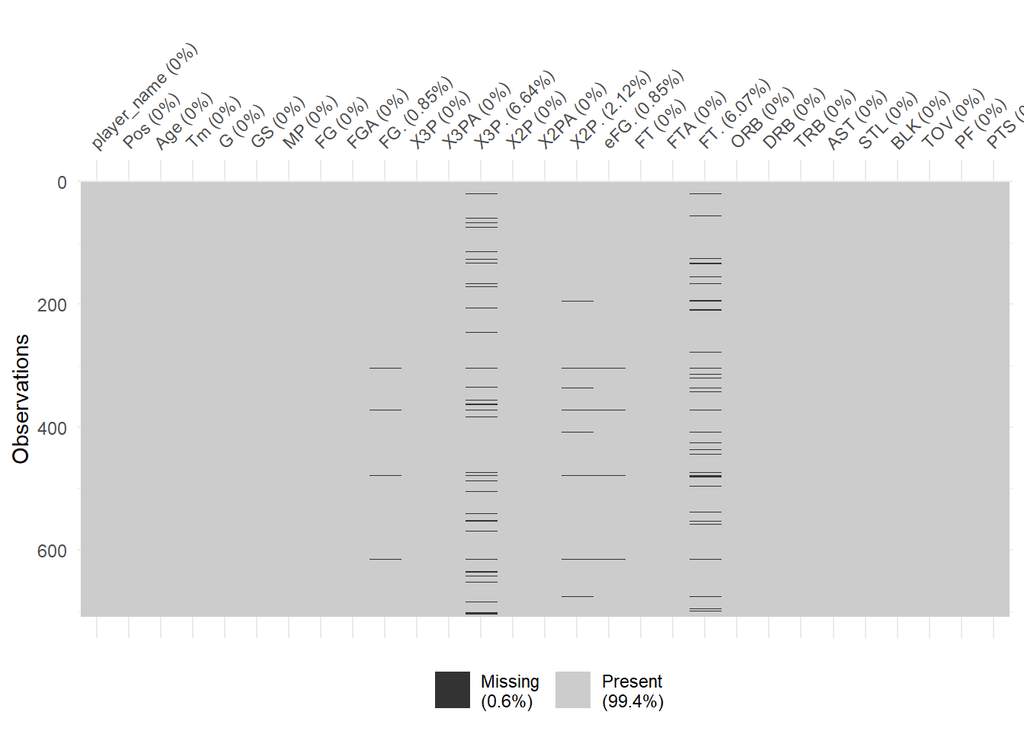

```r
naniar::vis_miss(df_player)
```

In this instance we can leave the na as converting to 0 will be inaccurate and the proportion of na data is 0.6% of all data.

### Join Player Statistics to Player Data

Since our budget is a major factor in selecting our starting roster we are going to join the player salaries to the player statistics table.

### Join Salary data to player data using left_join.

```r
df_player <- left_join(df_player, df_player_salaries, by = "player_name") # join salary to player statistics
```

### Check salaries have been added

```r
head(df_player)
```

```
##    player_name Pos Age  Tm  G GS   MP  FG FGA   FG. X3P X3PA  X3P. X2P X2PA
## 1 Alex Abrines  SG  25 OKC 31  2  588  56 157 0.357  41  127 0.323  15   30
## 2   Quincy Acy  PF  28 PHO 10  0  123   4  18 0.222   2   15 0.133   2    3
## 3 Jaylen Adams  PG  22 ATL 34  1  428  38 110 0.345  25   74 0.338  13   36
## 4 Steven Adams   C  25 OKC 80 80 2669 481 809 0.595   0    2 0.000 481  807
## 5  Bam Adebayo   C  21 MIA 82 28 1913 280 486 0.576   3   15 0.200 277  471
## 6    Deng Adel  SF  21 CLE 19  3  194  11  36 0.306   6   23 0.261   5   13
##    X2P.  eFG.  FT FTA   FT. ORB DRB TRB AST STL BLK TOV  PF  PTS player_id
## 1 0.500 0.487  12  13 0.923   5  43  48  20  17   6  14  53  165         1
## 2 0.667 0.278   7  10 0.700   3  22  25   8   1   4   4  24   17         2
## 3 0.361 0.459   7   9 0.778  11  49  60  65  14   5  28  45  108         4
## 4 0.596 0.595 146 292 0.500 391 369 760 124 117  76 135 204 1108         3
## 5 0.588 0.579 166 226 0.735 165 432 597 184  71  65 121 203  729         5
## 6 0.385 0.389   4   4 1.000   3  16  19   5   1   4   6  13   32         6
##     salary
## 1  3667645
## 2   213948
## 3   236854
## 4 24157304
## 5  2955840
## 6    77250
```

We can also join the team stats data togeather for ease of use. We will join by Team.

```r
df_team_stats_combined <- left_join(df_team_stats_1, df_team_stats_2, by = "Team") # join data
```

Note: We can’t join the team salaries with the team statistics as team names are not in the same format.

## Data Exploratory & Modeling

In order to find the best 5 starting roster we need to understand why teams win. According to the four factor method the team that is the most efficient is more likely to win based on the observations discussed earlier. Lets check `eFG.`. against `W` to start with.

In basketball, effective field goal percentage (abbreviated `eFG.`) is a statistic that adjusts field goal percentage to account for the fact that three-point field goals count for three points while field goals only count for two points. Its goal is to show what field goal percentage a two-point shooter would have to shoot at to match the output of a player who also shoots three-pointers.

Reference 2 - `eFG.` reference [here](https://en.wikipedia.org/wiki/Effective_field_goal_percentage#:~:text=From%20Wikipedia%2C%20the%20free%20encyclopedia,only%20count%20for%20two%20points)

Is there a relationship between `eFG.` and `W`?

### Lets plot eFG. vs Wins.

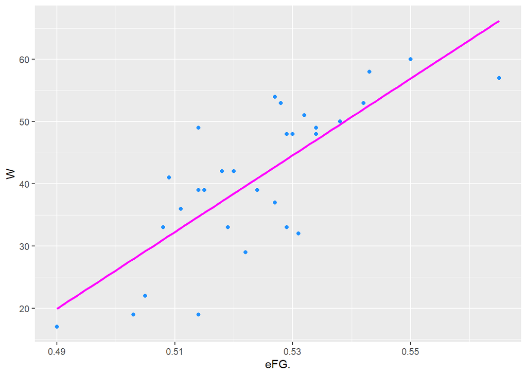

```r
ggplot(data = df_team_stats_combined, aes(x = eFG., y = W)) +
geom_point(colour = "dodgerblue") +
geom_smooth(method = "lm", colour = "magenta", se = FALSE)
```

There looks to be reasonably strong positive relationship between eFG & wins. Lets continue checking data.

### Check the co-efficent of variation

```r
with(df_team_stats_combined, cor(x = eFG., y = W))
```

```
## [1] 0.7818644
```

[1] 0.7818644 indicates a strong positive relationship between Wins and eFG percentage.

### Check whether the `eFG.` percentage influences `W`

```r
fit <- lm(eFG. ~ W, data = df_team_stats_combined)
tidy(fit, conf.int = TRUE)
```

```
## # A tibble: 2 x 7
##   term        estimate std.error statistic  p.value conf.low conf.high
##   <chr>          <dbl>     <dbl>     <dbl>    <dbl>    <dbl>     <dbl>
## 1 (Intercept) 0.484     0.00637      75.9  5.78e-34 0.470      0.497
## 2 W           0.000991  0.000149      6.64 3.36e- 7 0.000685   0.00130
```

```r
summary(fit)
```

```
##
## Call:
## lm(formula = eFG. ~ W, data = df_team_stats_combined)
##
## Residuals:
##        Min         1Q     Median         3Q        Max
## -0.0180942 -0.0078397  0.0001477  0.0056852  0.0249782
##
## Coefficients:
##              Estimate Std. Error t value Pr(>|t|)
## (Intercept) 0.4835380  0.0063720  75.884  < 2e-16 ***
## W           0.0009909  0.0001493   6.636 3.36e-07 ***
## ---
## Signif. codes:  0 '***' 0.001 '**' 0.01 '*' 0.05 '.' 0.1 ' ' 1
##
## Residual standard error: 0.009673 on 28 degrees of freedom
## Multiple R-squared:  0.6113, Adjusted R-squared:  0.5974
## F-statistic: 44.04 on 1 and 28 DF,  p-value: 3.365e-07
```

R-squared = 0.5974, meaning that 59.7% of the variance in wins is explained by the variance in eFG.

### Test Independence

```r
car::durbinWatsonTest(fit)
```

```
##  lag Autocorrelation D-W Statistic p-value
##    1    -0.009961279      2.001037    0.89
##  Alternative hypothesis: rho != 0
```

The result is 2.001 which ensures independence.

### Outliers

```r
std_res <- rstandard(fit)
points <- 1:length(std_res)
```

### Plot Outliers

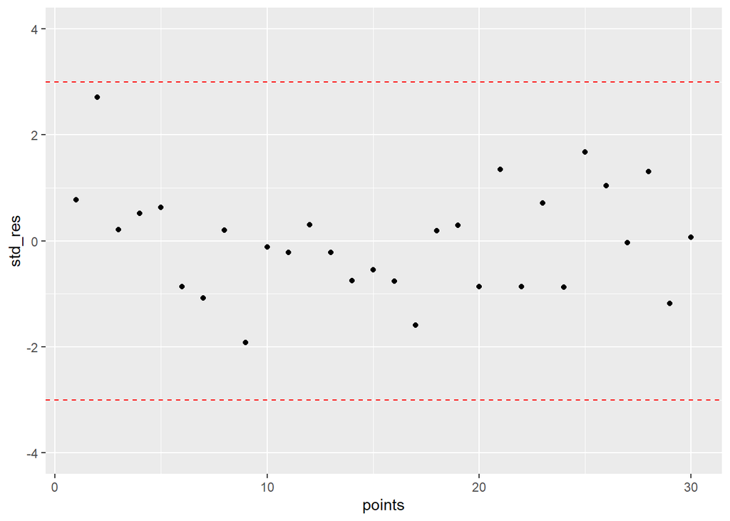

```r
ggplot(data = NULL, aes(x = points, y = std_res)) +
geom_point() +
ylim(c(-4,4)) +
geom_hline(yintercept = c(-3, 3), colour = "red", linetype = "dashed")
```

All data is within 3 standard deviations so there doesn’t appear to be any outliers.

### Determine leverage points

```r
hats <- hatvalues(fit)
```

### Plot Leverage Points

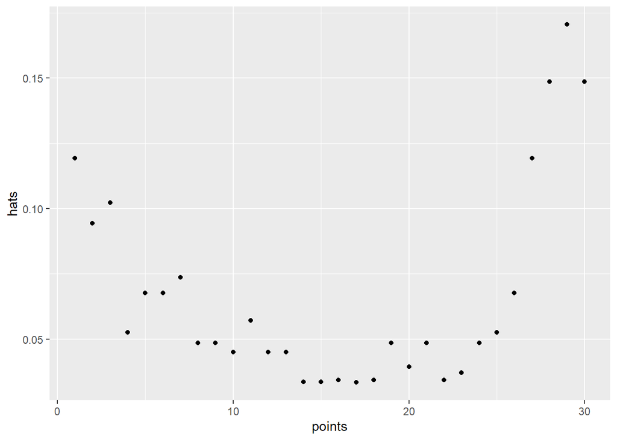

```r
ggplot(data = NULL, aes(x = points, y = hats)) +
geom_point()
```

There are no hat values greater than 1, we might investigate the points above 0.12 as these seem to stand out.

### Check for Homoscedasticity

```r
res <- residuals(fit)
fitted <- predict(fit)
```

### Plot Homoscedacity

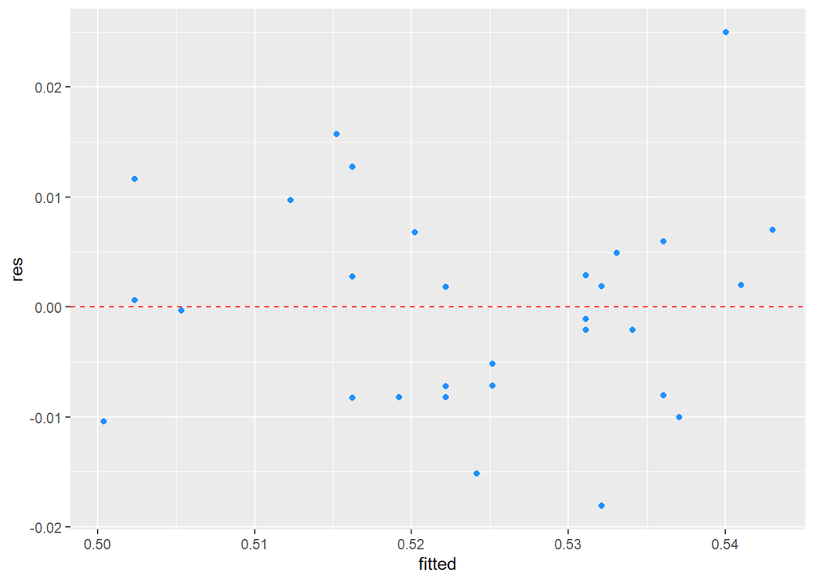

```r
ggplot(data = NULL, aes(x = fitted, y = res)) +
geom_point(colour = "dodgerblue") +
geom_hline(yintercept = 0, colour = "red", linetype = "dashed")
```

Heteroscedasticity doesn’t appear to be evident.

### Check for Normality

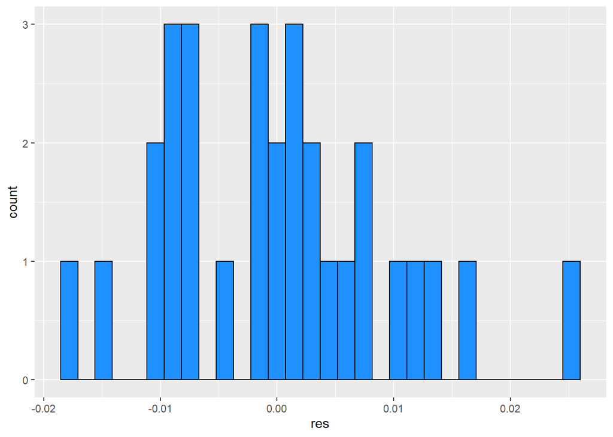

```r
ggplot(data = NULL, aes(x = res)) +
geom_histogram(colour = "black", fill = "dodgerblue", bins = 30)
```

The data appears to be normally distributed.

## Summary

### Pick up all Rebounds

If a team cannot score on every possession, then the optimal task is to grab every miss and give the team a second-chance opportunity. An offensive rebound extends a possession and allows for a second attempt at a field goal. This is effectively when teams get another chance to score.

To measure the quality of a team’s ability to rebound, we compute the offensive rebounding percentage `ORB%`. This quantity is calculated as the number of offensive rebounds divided by the number of available rebounds after a missed field goal attempt.

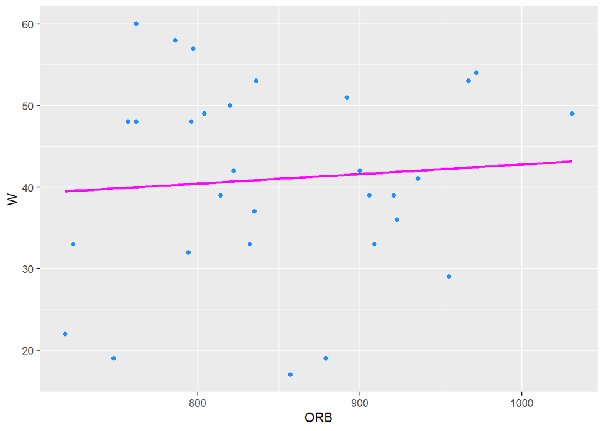

```r
ggplot(data = df_team_stats_combined, aes(x = ORB, y = W)) +
geom_point(colour = "dodgerblue") +
geom_smooth(method = "lm", colour = "magenta", se = FALSE)
```

There looks to be a weak positive relationship vs ORB. For the purpose of this analysis we will not use this as an effective variable to recruit new players.

### Free throw

The next way to score points other than scoring a field goal or giving the team a second opportunity is to get to the foul line.

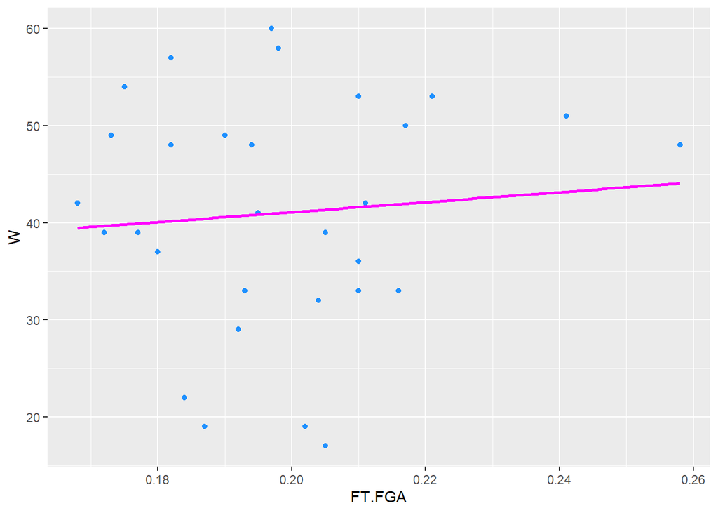

```r
ggplot(data = df_team_stats_combined, aes(x = FT.FGA, y = W)) +
geom_point(colour = "dodgerblue") +
geom_smooth(method = "lm", colour = "magenta", se = FALSE)
```

### Protect the Ball

The final step of the four factors is to ensure that teams don’t turn the ball over. This is a simple measurement called turnover percentage `TO%`. This measure is simply to calculate the percentage of possessions that ended in a turnover. The smaller the number the better.

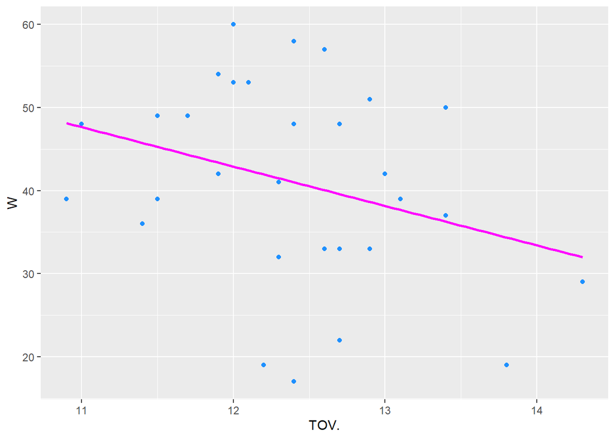

```r
ggplot(data = df_team_stats_combined, aes(x = TOV., y = W)) +
geom_point(colour = "dodgerblue") +
geom_smooth(method = "lm", colour = "magenta", se = FALSE)
```

There seems to be some realtionship present. Lets have a look at the correlation co-efficient to confirm how these are related.

```r
with(df_team_stats_combined, cor(x = TOV., y = W))
```

```
## [1] -0.3068775
```

[1] -0.3068775 the co-efficient of variation there is only a moderate to low correlation so we will not use this as a factor to recruit.

In summary it seems as though the most positive relationship on the variables we have checked appear to be effective field goal percentage.

Lets turn back to our player statistics.

## Player Satistics

As previusly discussed we know that `eFG.` has a influence on wins. In the next section we will try to wrangle the data to work out best players to recruit using the variable `eFG.`.

### Removing Duplicates from player who have played for more than one team.

Player names appear more than once if they have been traded so we need to remove the duplicates. For ease of use we have only kept distinct valves for player who are traded although this may not be best practice.

```r
df_player_1 <- df_player %>%
distinct(player_name, .keep_all = TRUE)
```

Note: The formula below was tried below but errors kept occurring and I wasn’t sure how to fix it.

df_player_1 <- aggregate(df_player[,5:31], list(df_player$player_name), FUN = sum)

### Removing players with small sample sizes

First lets filter the data to remove to remove players who have had small minutes `MP` and as we are looking at starting players we have removed players players who started in less than 10 games `GS`.

Since we are looking at `eFG.` we are also going to remove anyone who has had less than 100 FGA field goal attempts as this is a function of `eFG.`. Removing these will allow us to get somewhat more accurate data. we are going to write this to a new table called `df_player_1_filtered` df_player_1_filtered.

```r
df_player_1_filtered <- df_player_1 %>%
filter(GS > 10, MP > 100, FGA > 100)
```

```r
head(df_player_1_filtered)
```

```
##         player_name Pos Age  Tm  G GS   MP  FG  FGA   FG. X3P X3PA  X3P. X2P
## 1      Steven Adams   C  25 OKC 80 80 2669 481  809 0.595   0    2 0.000 481
## 2       Bam Adebayo   C  21 MIA 82 28 1913 280  486 0.576   3   15 0.200 277
## 3 LaMarcus Aldridge   C  33 SAS 81 81 2687 684 1319 0.519  10   42 0.238 674
## 4     Jarrett Allen   C  20 BRK 80 80 2096 335  568 0.590   6   45 0.133 329
## 5   Al-Farouq Aminu  PF  28 POR 81 81 2292 257  593 0.433  96  280 0.343 161
## 6     Kyle Anderson  SF  25 MEM 43 40 1281 150  276 0.543   9   34 0.265 141
##   X2PA  X2P.  eFG.  FT FTA   FT. ORB DRB TRB AST STL BLK TOV  PF  PTS player_id
## 1  807 0.596 0.595 146 292 0.500 391 369 760 124 117  76 135 204 1108         3
## 2  471 0.588 0.579 166 226 0.735 165 432 597 184  71  65 121 203  729         5
## 3 1277 0.528 0.522 349 412 0.847 251 493 744 194  43 107 144 179 1727        10
## 4  523 0.629 0.595 197 278 0.709 191 481 672 110  43 120 103 184  873        13
## 5  313 0.514 0.514 150 173 0.867 112 498 610 104  68  33  72 143  760        15
## 6  242 0.583 0.560  37  64 0.578  48 203 251 128  54  37  58 112  346        17
##     salary
## 1 24157304
## 2  2955840
## 3 22347015
## 4  2034120
## 5  6957105
## 6  8641000
```

```r
str(df_player_1_filtered)
```

```
## 'data.frame':    230 obs. of  31 variables:
##  $ player_name: chr  "Steven Adams" "Bam Adebayo" "LaMarcus Aldridge" "Jarrett Allen" ...
##  $ Pos        : chr  "C" "C" "C" "C" ...
##  $ Age        : int  25 21 33 20 28 25 24 24 33 31 ...
##  $ Tm         : chr  "OKC" "MIA" "SAS" "BRK" ...
##  $ G          : int  80 82 81 80 81 43 72 81 26 81 ...
##  $ GS         : int  80 28 81 80 81 40 72 32 26 81 ...
##  $ MP         : int  2669 1913 2687 2096 2292 1281 2358 1961 884 2269 ...
##  $ FG         : int  481 280 684 335 257 150 721 187 86 318 ...
##  $ FGA        : int  809 486 1319 568 593 276 1247 418 227 677 ...
##  $ FG.        : num  0.595 0.576 0.519 0.59 0.433 0.543 0.578 0.447 0.379 0.47 ...
##  $ X3P        : int  0 3 10 6 96 9 52 81 50 131 ...
##  $ X3PA       : int  2 15 42 45 280 34 203 217 139 311 ...
##  $ X3P.       : num  0 0.2 0.238 0.133 0.343 0.265 0.256 0.373 0.36 0.421 ...
##  $ X2P        : int  481 277 674 329 161 141 669 106 36 187 ...
```

[output cut: 17 more lines]

Lets print the players by position including the only necessary variables.

Lets look at the Centre with the highest `eFG.`

```r
df_player_1_filtered %>%
filter( Pos == "C") %>%
arrange(desc(eFG.)) %>%
select(player_name, Pos, eFG., salary)
```

```
##            player_name Pos  eFG.   salary
## 1    Mitchell Robinson   C 0.694  1485440
## 2          Rudy Gobert   C 0.669 23491573
## 3        Thomas Bryant   C 0.648  1378242
## 4         Clint Capela   C 0.648 15793104
## 5          Jakob Poltl   C 0.645       NA
## 6        Dwight Powell   C 0.637  9631250
## 7       DeAndre Jordan   C 0.634 22897200
## 8         Kevon Looney   C 0.627  1567007
## 9         JaVale McGee   C 0.625  2393887
## 10      Derrick Favors   C 0.600 16900000
## 11        Steven Adams   C 0.595 24157304
## 12       Jarrett Allen   C 0.595  2034120
## 13       Mason Plumlee   C 0.595 12917808
## 14       Jahlil Okafor   C 0.587  1567007
```

[output cut: 31 more lines]

Lets look at the Power Forward with the highest .eFG.

```r
df_player_1_filtered %>%
filter( Pos == "PF") %>%
arrange(desc(eFG.)) %>%
select(player_name, Pos, eFG., salary)
```

```
##              player_name Pos  eFG.   salary
## 1          Davis Bertans  PF 0.610  7000000
## 2  Giannis Antetokounmpo  PF 0.599 24157304
## 3           John Collins  PF 0.593  2299080
## 4          Pascal Siakam  PF 0.591  1544951
## 5             Taj Gibson  PF 0.576 14000000
## 6       Dante Cunningham  PF 0.570  2487000
## 7           Jerami Grant  PF 0.567  8333333
## 8        Nemanja Bjelica  PF 0.566  6500000
## 9             Joe Ingles  PF 0.565 12545455
## 10          Kelly Olynyk  PF 0.563 13537527
## 11        Thaddeus Young  PF 0.557 13764045
## 12            Jeff Green  PF 0.555  2393887
## 13         Julius Randle  PF 0.555  8641000
## 14              Rudy Gay  PF 0.554 10087200
```

[output cut: 28 more lines]

Lets look at the Shooting Guard with the highest .eFG.

```r
df_player_1_filtered %>%
filter( Pos == "SG") %>%
arrange(desc(eFG.)) %>%
select(player_name, Pos, eFG., salary)
```

```
##                 player_name Pos  eFG.   salary
## 1               Danny Green  SG 0.622 10000000
## 2                Joe Harris  SG 0.622  8333333
## 3             Malik Beasley  SG 0.584  1773840
## 4             Landry Shamet  SG 0.576  1705920
## 5           Malcolm Brogdon  SG 0.575  1544951
## 6               Bryn Forbes  SG 0.568  3125000
## 7               Buddy Hield  SG 0.560  3833760
## 8                 JJ Redick  SG 0.557 12250000
## 9             E'Twaun Moore  SG 0.553  8808685
## 10            Klay Thompson  SG 0.553 18988725
## 11        Terrance Ferguson  SG 0.552  2118840
## 12             Dwayne Bacon  SG 0.549  1378242
## 13             Bradley Beal  SG 0.540 25434262
## 14            Avery Bradley  SG 0.537 12000000
```

[output cut: 37 more lines]

Lets look at the Point Guard with the highest .eFG.

```r
df_player_1_filtered %>%
filter( Pos == "PG") %>%
arrange(desc(eFG.)) %>%
select(player_name, Pos, eFG., salary)
```

```
##                player_name Pos  eFG.   salary
## 1            Stephen Curry  PG 0.604 37457154
## 2              George Hill  PG 0.575 19000000
## 3              DJ Augustin  PG 0.566  7250000
## 4              Ben Simmons  PG 0.563  6434520
## 5             Kyrie Irving  PG 0.557 20099189
## 6             Eric Bledsoe  PG 0.548 15000000
## 7         Tomas Satoransky  PG 0.545  3129187
## 8         Ryan Arcidiacono  PG 0.544  1349383
## 9             James Harden  PG 0.541 30570000
## 10         Darren Collison  PG 0.527 10000000
## 11        Patrick Beverley  PG 0.524  5027028
## 12           Jalen Brunson  PG 0.523  1230000
## 13           Derrick White  PG 0.523  1667160
## 14          Damian Lillard  PG 0.522 27977689
```

[output cut: 34 more lines]

```r
df_player_1_filtered %>%
filter( Pos == "SF") %>%
arrange(desc(eFG.)) %>%
select(player_name, Pos, eFG., salary)
```

```
##                player_name Pos  eFG.   salary
## 1             Danuel House  SF 0.615   247827
## 2              Otto Porter  SF 0.580 26011913
## 3           Andre Iguodala  SF 0.579 16000000
## 4              Jake Layman  SF 0.579  1544951
## 5         Bojan Bogdanovic  SF 0.575 10500000
## 6            Royce O'Neale  SF 0.574  1378242
## 7             Kevin Durant  SF 0.571 30000000
## 8           Justin Jackson  SF 0.568  2807880
## 9               Tony Snell  SF 0.564 10607143
## 10           Kyle Anderson  SF 0.560  8641000
## 11            LeBron James  SF 0.560 35654150
## 12        Robert Covington  SF 0.556 10464092
## 13        Danilo Gallinari  SF 0.554 21587579
## 14           Nicolas Batum  SF 0.553 24000000
```

[output cut: 30 more lines]

# 5.Final Recommendations

To discover players that had a greater impact on winning we used the four factors model that references 4 variables. During the exploratory analysis phase we saw that .eFG% had the greatest impact on wining games and thus it was used as the main variable in our analysis. We can see that this statistic can sometimes be underrated vs salary as you can see in the instance of Danuel House.